# Introduction to Bayesian Marginal Additive Models

Tianyi Pan

2022-05-12

In this document, we illustrate R functions for Bayesian marginal additive models (BMAM).

## Brief overview of Bayesian marginal additive models

Heagerty and Zeger (2000) presented the marginal models in which the marginal mean, rather than the conditional mean given random effects, is regressed on covariates. Marginal models are useful when we are interested in associations averaged across a population of clusters. If the covariate-outcome association is unknown, we could use additive models to measure the potentially non-linear relationships. McGee and Stringer (2022) proposed a marginal additive model (MAM) for modeling dependent data with non-linear population-averaged associations. The [R package](https://github.com/awstringer1/mam) for MAM is available.

We propose a Bayesian marginal additive model (BMAM) to extend the marginal additive model (MAM) into a Bayesian context.

### Bayesian conditional models

We consider a Generalized Additive Mixed Model (GAMM),
$$g\left\{\mu^{\mathrm{C}}\left(\boldsymbol{x}_{i j}, \boldsymbol{z}_{i j} \mid \boldsymbol{u}_{i}\right)\right\}=\sum_{l=1}^{p} f_{l}^{\mathrm{C}}\left(x_{i j l}\right)+\boldsymbol{z}_{i j}^{\mathrm{T}} \boldsymbol{u}_{i}$$
where $i = 1,\cdots,N$ indexes clusters and $j = 1, \cdots, n_i$ indexes units within clusters. Random effects $\boldsymbol{u}_{i}$ follow a normal distribution with mean 0 and covariance matrix $\boldsymbol{\Sigma}=\boldsymbol{\Lambda}\left(\boldsymbol{\sigma}\right) \boldsymbol{\Omega} \boldsymbol{\Lambda}\left(\boldsymbol{\sigma}\right)$, where $\boldsymbol{\Lambda}\left(\boldsymbol{\sigma}\right)$ denoted the the diagonal matrix with diagonal elements $\boldsymbol{\sigma}$.

$f_{l}^{\mathrm{C}}(x)=\sum_{q=1}^{d_{l}} b_{l q}^{\mathrm{C}}(x) \alpha_{l q}^{\mathrm{C}}$ are unknown smooth functions. Each $\boldsymbol{\alpha}_{l}^{\mathrm{C}}$ is associated with a penalty $\mathcal{P}_{\tau_{l}^{\mathrm{C}}}\left(\boldsymbol{\alpha}_{l}^{\mathrm{C}} ; \boldsymbol{S}_{l}\right) \propto \mathrm{exp} \left( - \tau_{l} \boldsymbol{\alpha}_{l}^{\mathrm{C}^\mathrm{T}} \boldsymbol{S}_{l} \boldsymbol{\alpha}_{l}^{\mathrm{C}} \right)$.

According to Wood (2006), $\sum_{q=1}^{d_{l}} b_{l q}^{\mathrm{C}}(x) \alpha_{l q}^{\mathrm{C}}$ can be written as $\sum_{q=1}^{d_{l}} b_{l q}^{*\mathrm{C}}(x) \alpha_{l q}^{*\mathrm{C}}$. Then the penalty can be termed as a prior distribution,
$$\alpha_{l k}^{*\mathrm{C}} \sim \mathrm{N}(0,\frac{1}{\tau_{l}}), k=3,\cdots,d_{l},$$
where $\left[ b_{l 1}^{*\mathrm{C}}(x), b_{l 2}^{*\mathrm{C}}(x), \cdots, b_{l d_{l}}^{*\mathrm{C}}(x)\right] = \left[ b_{l 1}^{\mathrm{C}}(x), b_{l 2}^{\mathrm{C}}(x), \cdots, b_{l d_{l}}^{\mathrm{C}}(x)\right] \mathbf{D}_{l+}^{-1}$, $\mathbf{D}_{l+} = \left[\begin{array}{cc} \mathbf{I}_{2} \ \ \mathbf{0} \\ \mathbf{D}_l \end{array}\right]$. and $\mathbf{D}_l$ is a $(d_{l}-2)\times d_{l}$ matrix with $\mathbf{D}_l^\mathrm{T} \mathbf{D}_l = S_l$

Thus, the GAMM can be rewritten as,

$$\begin{aligned}
g\left\{\mu^{\mathrm{C}}\left(\boldsymbol{x}_{i j}, \boldsymbol{z}_{i j} \mid \boldsymbol{u}_{i}\right)\right\}&=\sum_{l=1}^{p} \sum_{q=1}^{d_{l}} b_{l q}^{*\mathrm{C}}(x) \alpha_{l q}^{*\mathrm{C}}+\boldsymbol{z}_{i j}^{\mathrm{T}} \boldsymbol{u}_{i},\\
\boldsymbol{u}_{i} &\sim \mathrm{N}(0,\boldsymbol{\Lambda}\left(\boldsymbol{\sigma}\right) \boldsymbol{\Omega} \boldsymbol{\Lambda}\left(\boldsymbol{\sigma}\right)),\\
\alpha_{l k}^{*\mathrm{C}} &\sim \mathrm{N}(0,\frac{1}{\tau_{l}}), k=3,\cdots,d_{l}.
\end{aligned}$$
Besides the two parameters $\boldsymbol{u}_{i}$ and $\alpha_{l k}^{*\mathrm{C}},k=3,\cdots,d_{l}$, in Bayesian model, we need to assign prior distributions for $\alpha_{l 1}^{*\mathrm{C}},\alpha_{l 2}^{*\mathrm{C}}$, $\tau_l$, $\boldsymbol{\sigma}$ and $\boldsymbol{\Omega}$.

### Bayesian marginal additive models

The Bayesian marginal additive models (BMAM) is,
$$g\left\{\mu^{\mathrm{M}}\left(\boldsymbol{x}_{i j}\right)\right\}=f^{\mathrm{M}}\left(\boldsymbol{x}_{i j}\right)$$
where $f^{\mathrm{M}}\left(\boldsymbol{x}_{i j}\right) = \sum_{l=1}^{p} f_{l}^{\mathrm{M}}\left(x_{i j l}\right) = \sum_{l=1}^{p}\sum_{q=1}^{Q_{l}} b_{l q}^{\mathrm{M}}(x) \alpha_{l q}^{\mathrm{M}}$. The inference on parameters $\alpha_{l q}^{\mathrm{M}}$ is based on the Bayesian conditional model through post-hoc marginalization (Hedeker et al. 2018). More details about the relationship between marginal additive models and conditional models can be found in McGee and Stringer (2022).

In practice, we could draw the posterior samples in conditional models by `brms` function. For each posterior sample, an estimate of $\alpha_{lq}^{\mathrm{M}}$ could be calculated. Assuming $H$ samples are drawn from posterior distribution in the conditional model, we could obtain $H$ estimates of $\alpha_{lq}^{\mathrm{M}}$, and then make an inference on $\alpha_{lq}^{\mathrm{M}}$ by the $H$ estimates.

## Basic example of Bayesian marginal additive models

We use the function `SimData` to generate some data, to illustrate the main features of our R functions for BMAM. The data are generated according to the set up in McGee and Stringer (2022). We consider the binary case, where the outcome variable $Y$ follows a Bernoulli distribution. The link function $g(\cdot)$ is set as logit function.

We generate three covariates $\boldsymbol{x}_{i j}=\left(x_{i j 1}, x_{i j 2}, x_{i j 3}\right)^{\mathrm{T}}$ where $x_{i j p} \sim \operatorname{Unif}(-1,1)$ for $p=1,2,3$. After assuming the forms of smooth functions $f_{1}^{\mathrm{M}}(\cdot)$ and $f_{2}^{\mathrm{M}}(\cdot)$, we could generate $Y_{ij}$ according to the marginal model,
$$\operatorname{logit}\left\{\mu^{\mathrm{M}}\left(\boldsymbol{x}_{i j}\right)\right\}=f_{1}^{\mathrm{M}}\left(x_{i j 1}\right)+f_{2}^{\mathrm{M}}\left(x_{i j 2}\right)+\beta_{3} \cdot x_{i j 3}.$$
In addition, we have the following random intercepts and slopes dependence structure,

$$\begin{aligned}
\operatorname{logit}\left\{\mu^{\mathrm{C}}\left(\boldsymbol{x}_{i j} \mid u_{i}\right)\right\} &=\Delta\left(\boldsymbol{x}_{i j}\right)+u_{i 0}+u_{i 1} \cdot x_{i j 3} \\
{\left[\begin{array}{l}
u_{i 0} \\
u_{i 1}
\end{array}\right] } & \sim M V N\left(\left[\begin{array}{l}
0 \\
0
\end{array}\right],\left[\begin{array}{cc}
4 & 1 \\
1 & 1
\end{array}\right]\right)
\end{aligned}$$

Here we set $\beta_3 = 0$, the number of cluster $N = 100$ and the number of units within clusters $n_i = 10, \forall i \in\{1, \ldots, N\}$.

```r
set.seed(4321)
simdata <- SimData(K = 100, Nk = 10)
dat <- simdata$data
fun <- simdata$f

head(dat)
```

```
#>   id intercepts    slopes     x1     x2     x3        fx1         fx2 y
#> 1  1 0.00418754 0.7360654 -0.330  0.961  0.170 -0.6311130 -1.68013950 0
#> 2  1 0.00418754 0.7360654  0.818 -0.099  0.043 -0.8243181 -0.03871960 0
#> 3  1 0.00418754 0.7360654 -0.177 -0.329  0.236 -0.4377683 -0.38827650 1
#> 4  1 0.00418754 0.7360654 -0.912 -0.377 -0.130  1.4145721 -0.49354654 1
#> 5  1 0.00418754 0.7360654  0.527  0.715  0.582  0.4406070 -1.27718865 0
#> 6  1 0.00418754 0.7360654  0.501  0.095  0.521  0.4979926 -0.03568155 0
```

where `simdata$data` is the dataset we generate and `simdata$f` is the smooth functions $f_{1}^{\mathrm{M}}(\cdot)$ and $f_{2}^{\mathrm{M}}(\cdot)$.

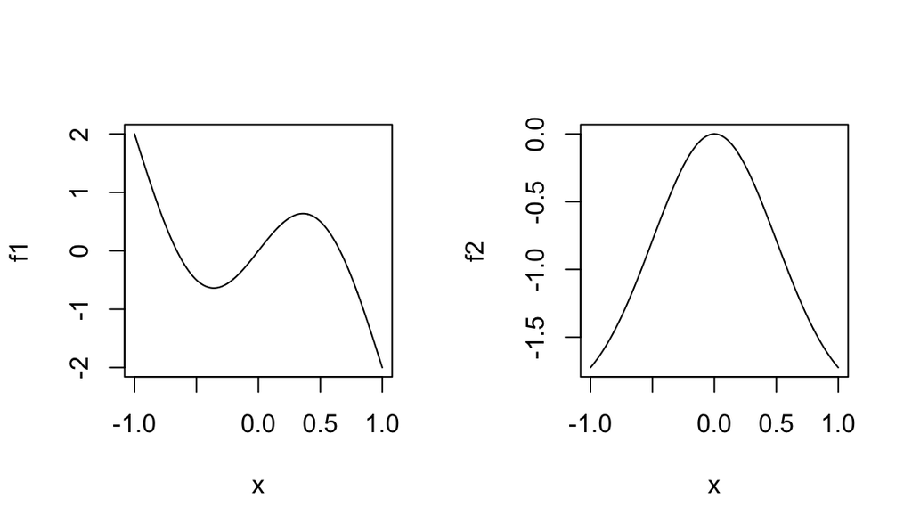

```r
x = seq(-1,1,length=1000)
f1 <- fun[[1]](x)
f2 <- fun[[2]](x)
par(mfrow = c(1,2))
plot(x, f1, type = "l")
plot(x, f2, type = "l")
```

### Fit BMAM

The BMAM is based on Bayesian GAMM, which could fitted by `brm` function in `brms` package.

```r
library(brms)
model_brms <- brm(bf(y ~  x3 + s(x1) + s(x2) + (1+x3|id)),
                  data = dat, family = "bernoulli",
                  cores = 4, seed = 4321,
                  warmup = 1000, iter = 2000, chains = 4,
                  refresh=0, backend = "cmdstanr")
```

```
#> Running MCMC with 4 parallel chains...
#>
#> Chain 3 finished in 26.1 seconds.
#> Chain 4 finished in 26.4 seconds.
#> Chain 1 finished in 26.9 seconds.
#> Chain 2 finished in 27.8 seconds.
#>
#> All 4 chains finished successfully.
#> Mean chain execution time: 26.8 seconds.
#> Total execution time: 28.2 seconds.
```

The setting of `brm` function can be found in Bürkner (2017). We use `bf()` to specify a formula containing smooth term and random effects. The GAMM is specified as a logistic model and we sample 4 chains with 2000 iterations (the first 1000 iterations are warm-up). It should noted that our `BMAM` functions only support the [`cmdstanr` backend](https://mc-stan.org/cmdstanr/).

Then, we draw the trace plots to check the convergence in Hamiltonian Monte Carlo in `brms` and the density plots of the posterior samples.

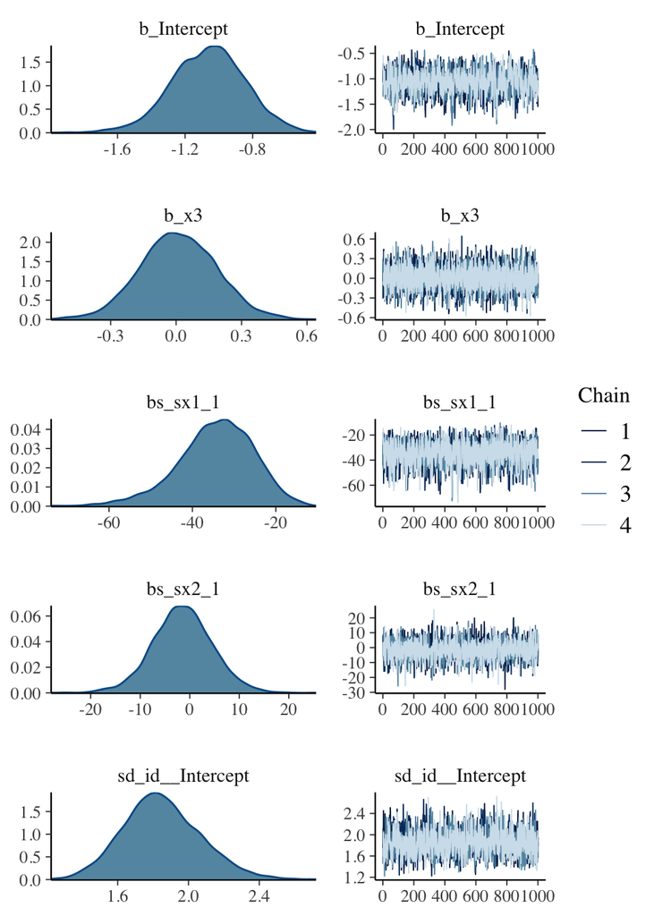

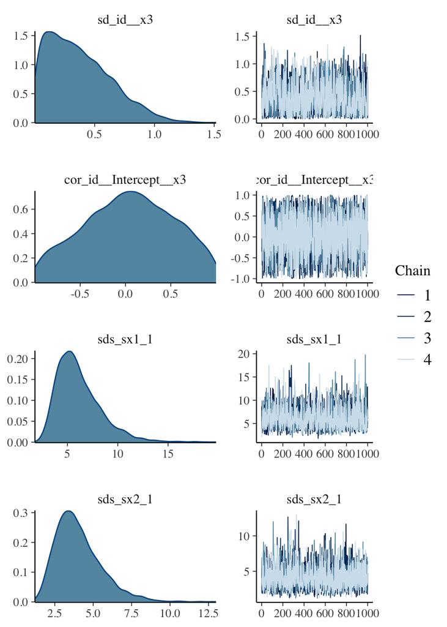

```r
plot(model_brms)
```

`BMAM` functions are built on `brmsmargins` package. We firstly load the dependent packages,

```r
library(brmsmargins)
library(data.table)
library(dplyr)
library(ggplot2)
```

To fit the BMAM, we use the `bmam` function.

```r
bmam <- bmam(object = model_brms, k=100, CIType="ETI", CI = 0.95)
```

where we pass pass the fitted GAMM object `model_brms` to `bmam` function. Monte Carlo method is used to integrate out the random effects, and we set the random draws as `k = 100` (default). The type of credible intervals (CI) can be specified by `CIType`. In this example, we use Equal-Tailed Interval, ETI (default). Please see [here](https://easystats.github.io/bayestestR/reference/ci.html) for more `CIType` options. The probability of CI is chosen as 95%.

### Summarize model

Let’s now summarize the fitted BMAM. The `summary` function will return a list of data frame. Each data frame contains the summary of posterior distribution of the coefficients of smooth functions $\alpha_l^{\mathrm{M}}$, such that $f_{l}^{\mathrm{M}}(x)=\sum_{q=1}^{Q_{l}} b_{l q}^{\mathrm{M}}(x) \alpha_{l q}^{\mathrm{M}}, l=1,\cdots,q$.

```r
bmam.summary <- summary(bmam)
```

```
#>
#> Family: bernoulli
#> Link function: logit
#>
#> y ~ x3 + s(x1) + s(x2) + (1 + x3 | id)
```

```r
knitr::kable(bmam.summary[[1]], digits = 3)
```

| Parameter | M | Mdn | LL | UL | CI | CIType |
| --- | --- | --- | --- | --- | --- | --- |
| Xs_1_alpha | -23.929 | -23.392 | -38.899 | -12.811 | 0.95 | ETI |
| Zs_1_1_alpha_1 | -1.599 | -1.258 | -10.652 | 5.500 | 0.95 | ETI |
| Zs_1_1_alpha_2 | -0.719 | -0.792 | -4.887 | 3.649 | 0.95 | ETI |
| Zs_1_1_alpha_3 | 8.046 | 7.933 | 5.158 | 11.591 | 0.95 | ETI |
| Zs_1_1_alpha_4 | -0.102 | -0.095 | -2.352 | 2.125 | 0.95 | ETI |
| Zs_1_1_alpha_5 | -0.441 | -0.516 | -5.365 | 4.734 | 0.95 | ETI |
| Zs_1_1_alpha_6 | -0.706 | -0.640 | -5.863 | 3.727 | 0.95 | ETI |
| Zs_1_1_alpha_7 | -2.127 | -1.828 | -9.691 | 3.951 | 0.95 | ETI |
| Zs_1_1_alpha_8 | -4.862 | -4.348 | -14.448 | 1.821 | 0.95 | ETI |

```r
knitr::kable(bmam.summary[[2]], digits = 3)
```

| Parameter | M | Mdn | LL | UL | CI | CIType |
| --- | --- | --- | --- | --- | --- | --- |
| Xs_2_alpha | -0.921 | -0.932 | -9.405 | 7.448 | 0.95 | ETI |
| Zs_2_1_alpha_1 | 0.296 | 0.221 | -4.931 | 5.691 | 0.95 | ETI |
| Zs_2_1_alpha_2 | -1.076 | -0.910 | -5.332 | 2.288 | 0.95 | ETI |
| Zs_2_1_alpha_3 | 0.117 | 0.128 | -2.165 | 2.383 | 0.95 | ETI |
| Zs_2_1_alpha_4 | -4.781 | -4.694 | -7.559 | -2.479 | 0.95 | ETI |
| Zs_2_1_alpha_5 | -0.079 | -0.092 | -4.138 | 4.124 | 0.95 | ETI |
| Zs_2_1_alpha_6 | 0.106 | 0.082 | -3.956 | 4.242 | 0.95 | ETI |
| Zs_2_1_alpha_7 | 0.084 | 0.080 | -5.074 | 5.147 | 0.95 | ETI |
| Zs_2_1_alpha_8 | 0.272 | 0.229 | -4.773 | 5.529 | 0.95 | ETI |

For each parameter, the `summary` function can return us the following information,

- M: the mean of the posterior samples
- Mdn: the median of the posterior samples
- LL: the lower limit of the credible interval
- UL: the upper limit of the credible interval
- CI: the probability of credible interval
- CIType: the type of credible interval

The default dimension of coefficients $\alpha_l^{\mathrm{M}}$ is 10, i.e. $Q_{1} = Q_{2} = 10$ in this example. The first parameter $\alpha_{l 1}^{\mathrm{M}}$ is the intercept, and we only report the coefficients $\alpha_{l q}^{\mathrm{M}}, q=2,3,\cdots,Q_l$.

### Visualize model

We also provide a `plot` function to visualize the estimated smooth functions, i.e. $\hat{f}^{\mathrm{M}}(\mathbf{X})$.

The `bmam` function will call the built in function `generate_pred` to generate the predicted function to illustrate the estimated smooth functions. The predicted data are generated according to the model and data used to fit the model. In this example, we use the simulated data `simdata$data` to fit the model `bf(y ~ x3 + s(x1) + s(x2) + (1+x3|id))`. The function will generate a sequence with length is 100 (default) from the minimum value of `x1` to maximum value of `x1` in `simdata$data`, denoted as $\tilde{X_1}$, and a sequence with length is 100 (default) from the minimum value of `x2` to maximum value of `x2` in `simdata$data`, denoted as $\tilde{X_2}$. The length of sequence can be set as the other value by passing to argument `length`, for example,

```r
bmam(object = model_brms, k=100, CIType="ETI", CI = 0.95,
     length = 200)
```

In addition, users can also provide a predicted data, for example,

```r
bmam(object = model_brms, k=100, CIType="ETI", CI = 0.95,
     preddat = user.preddat)
```

The `plot` function will show the plot of $\hat{f}^{\mathrm{M}}(X_1)$ and $\hat{f}^{\mathrm{M}}(X_2)$.

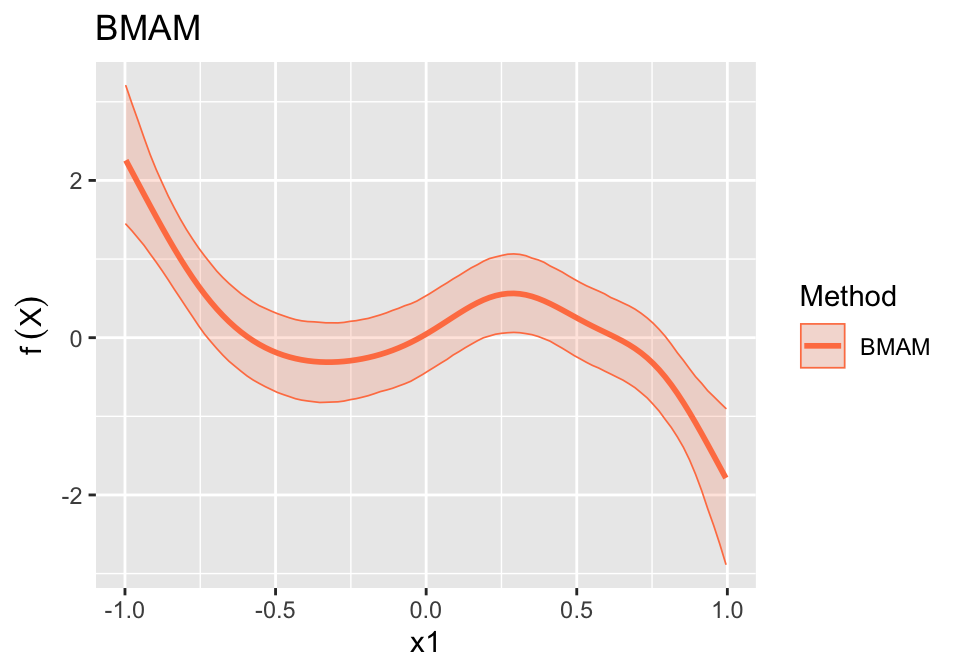

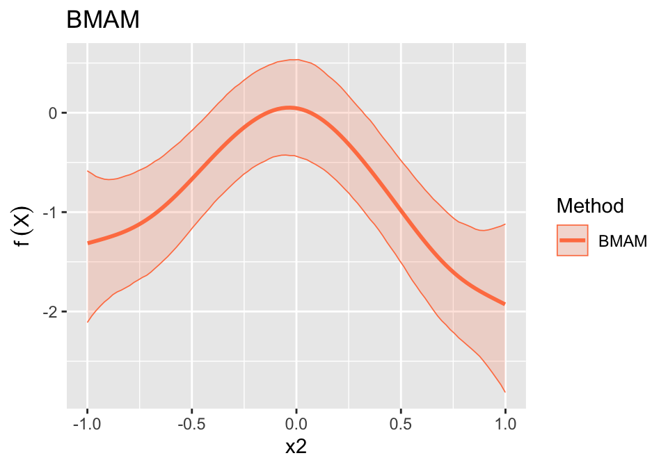

```r
plot(bmam)
```

We could also provide the the true forms of smooth functions `simdata$f` to the `plot` function to compare $\hat{f}^{\mathrm{M}}(\mathbf{X})$ and $f^{\mathrm{M}}(\mathbf{X})$,

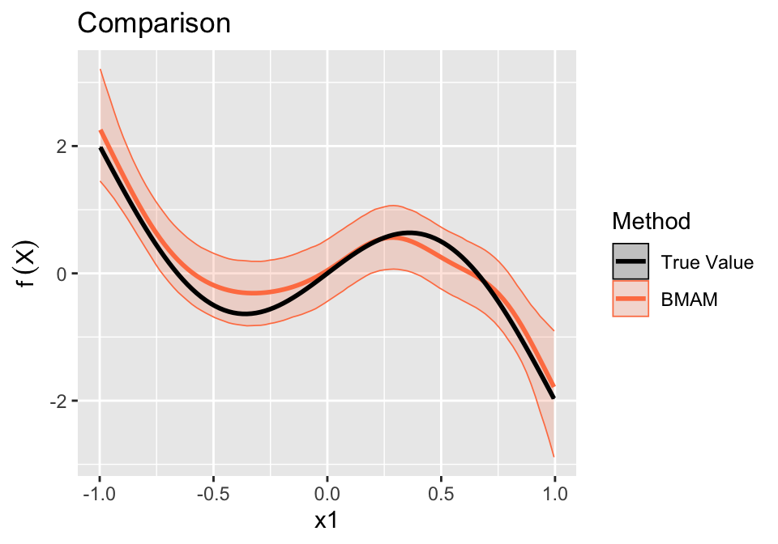

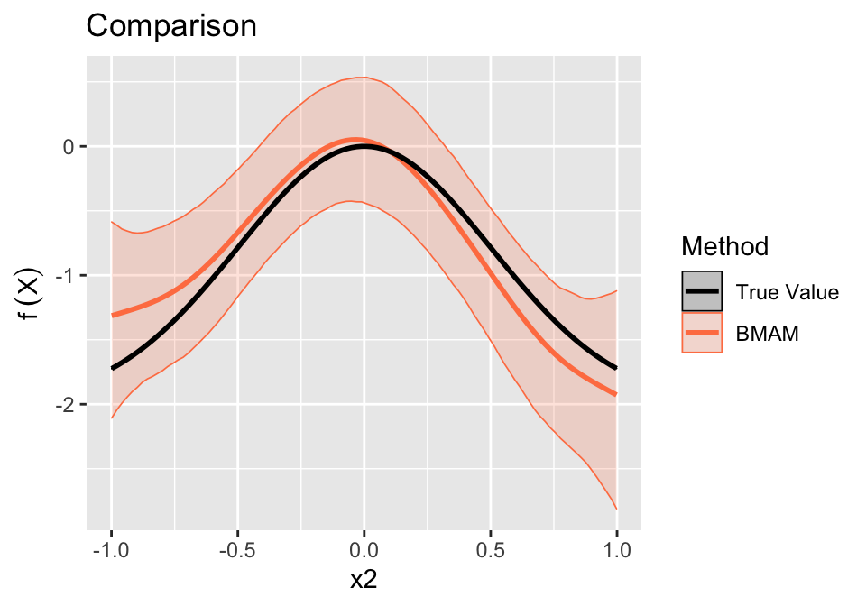

```r
plot(bmam, smooth.function = simdata$f)
```

### Compare with other models

The argument `compared.model` in `plot` function allows us to provide the other model compared with BMAM.

The supported models include

- Marginal additive model by `mam` package
- Generalized additive model by `mgcv` package
- Bayesian generalized additive model by `brms` package

#### Marginal additive model

The frequentist marginal additive model can be fitted by `mam` function in `mam` package (McGee and Stringer 2022). The predicted data in the `mam` should the same as that we used in `bmam`. We can obtain the generated predicted data from the fitted `bmam` object by `bmam$Preddat`.

```r
library(mam)
library(mgcv)
```

```r
themam <- mam(smooth = list(s(x1),s(x2)),
                   re = y ~ (1+x3|id),
                   fe = ~ x3,
                   dat = dat,
                   margdat = dat,
                   preddat = bmam$Preddat,
                   control = mam_control(
                     method = 'trust',
                     varmethod = 1,
                     verbose = FALSE,
                     retcond = TRUE))
```

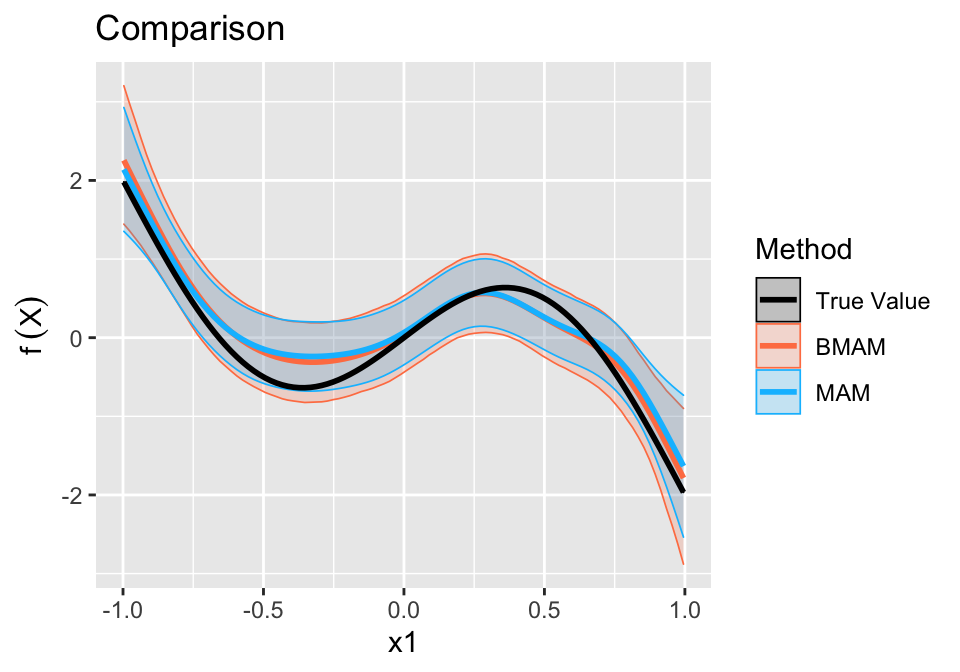

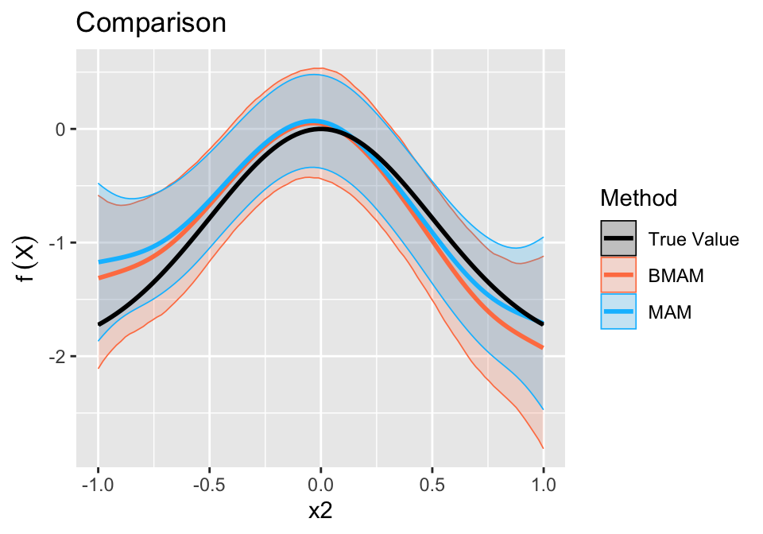

```r
plot(bmam, compared.model = themam, smooth.function = simdata$f)
```

#### Generalized additive model

We could also compare the BMAM with GAM. The `plot` function now support the Generalized additive model by `mgcv` package and Bayesian generalized additive model by `brms` package.

```r
gam <- gam(y ~  x3 + s(x1) + s(x2),
           data=dat,family=binomial(),method="REML")
```

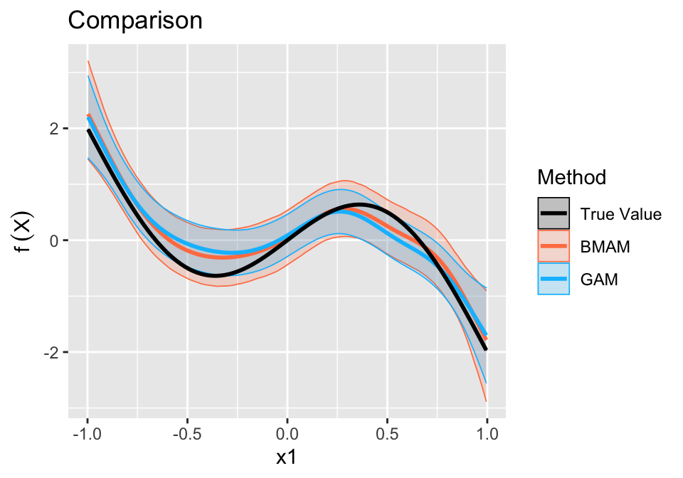

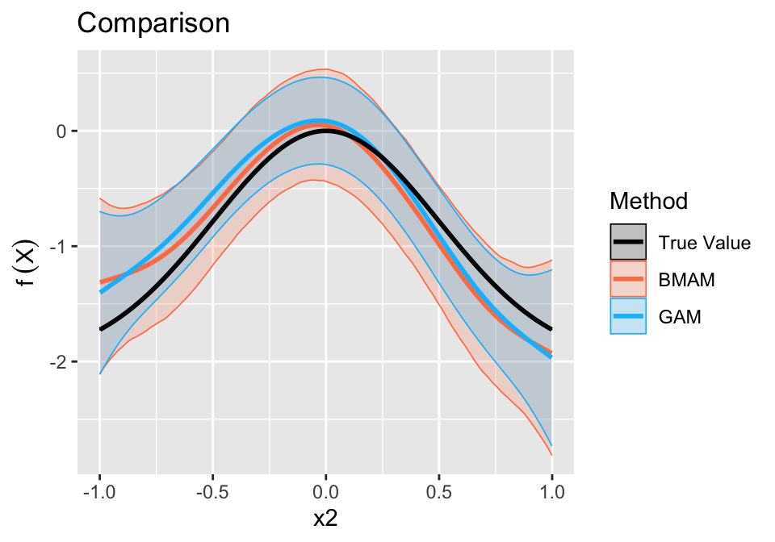

```r
plot(bmam, compared.model = gam, smooth.function = simdata$f)
```

```r
bgam <- brm(bf(y ~  x3 + s(x1) + s(x2)), data = dat,
            family = "bernoulli",
            cores = 4, seed = 4321, warmup = 1000,
            iter = 2000, chains = 4,
            refresh=0, backend = "cmdstanr")
```

```
#> Running MCMC with 4 parallel chains...
#>
#> Chain 4 finished in 14.4 seconds.
#> Chain 2 finished in 15.3 seconds.
#> Chain 1 finished in 15.5 seconds.
#> Chain 3 finished in 16.2 seconds.
#>
#> All 4 chains finished successfully.
#> Mean chain execution time: 15.4 seconds.
#> Total execution time: 16.4 seconds.
```

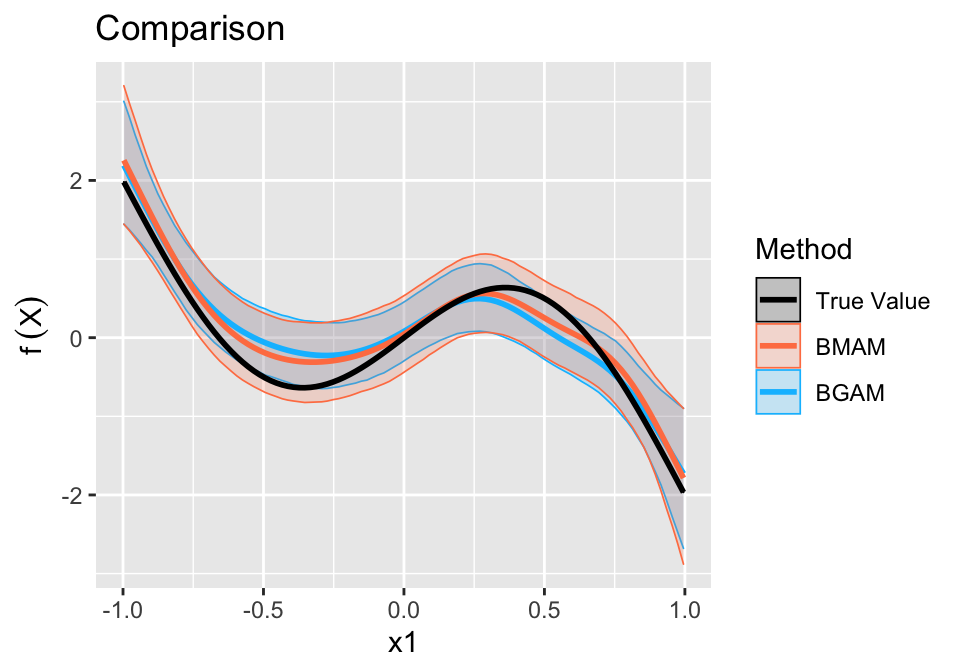

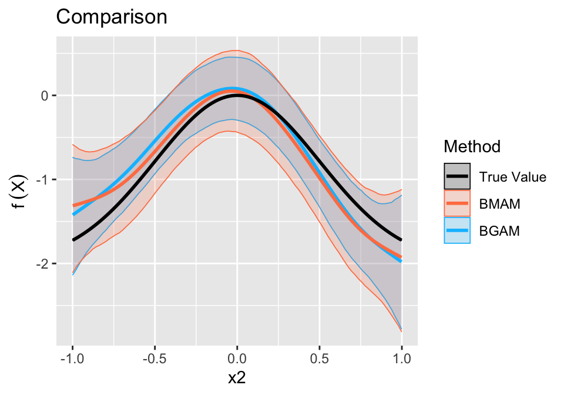

```r
plot(bmam, compared.model = bgam, smooth.function = simdata$f)
```

## References

Bürkner, Paul-Christian. 2017. “Brms: An r Package for Bayesian Multilevel Models Using Stan.” *Journal of Statistical Software* 80: 1–28.

Heagerty, Patrick J, and Scott L Zeger. 2000. “Marginalized Multilevel Models and Likelihood Inference.” *Statistical Science* 15 (1): 1–26.

Hedeker, Donald, Stephen HC du Toit, Hakan Demirtas, and Robert D Gibbons. 2018. “A Note on Marginalization of Regression Parameters from Mixed Models of Binary Outcomes.” *Biometrics* 74 (1): 354–61.

McGee, Glen, and Alex Stringer. 2022. “Flexible Marginal Models for Dependent Data.” *arXiv Preprint arXiv:2204.07188*.

Wood, Simon N. 2006. *Generalized Additive Models: An Introduction with r*. chapman; hall/CRC.